Skip to main content

# Differential Expression Analysis of Chromosome X RNA-seq Data

Bioinformatics

Statistics

R

Sex-based differential expression on chromosome X from 12 paired-end RNA-seq samples, using a Nextflow pipeline with HISAT2 and StringTie, and Ballgown in R.

Author

Devon Allies, BSc Hons. Bioinformatics & Computational Biology

Published

May 2026

## Overview

This analysis evaluates transcriptional variations on Chromosome X (chrX) between male and female individuals to uncover sex-specific dynamics. This study utilises a cohort of 12 paired-end RNA Sequencing (RNAseq) samples obtained from distinct geographical populations. By adjusting for population structure, this analysis isolates robust sex-linked genetic expression underlying chromosome-wide regulation mechanisms.

## Methods

### Data Processing

Raw paired-end sequencing reads were processed using a reproducible, custom Nextflow DSL2 pipeline hosted at [github.com/DevonAllies/rnaseq-pipeline](https://github.com/DevonAllies/rnaseq_pipeline/tree/main). The computational workflow was systemically executed using the following steps:

| Step | Tool | Purpose |
| --- | --- | --- |
| Quality Control (QC) | FastQC | Assess raw read quality |
| Adapter trimming | Trim Galore | Remove sequencing adapters |
| Alignment | HISAT2 | Splice-aware alignment to chrX |
| Assembly | StringTie | Per-sample transcript quantification |
| Merging | StringTie merge | Consensus transcriptome across samples |
| Re-estimation | StringTie | Re-quantify against merged Gene Transfer Format (GTF) |
| QC report | MultiQC | Aggregate quality metrics |

The pipeline execution was controlled via the baseline terminal command:

```bash
nextflow run rnaseq.nf -profile local --hisat2_prefix indexes/chrX_tran
```

### Differential Expression

Downstream Differential Expression (DE) modelling was performed at the gene level using the [Ballgown](https://bioconductor.org/packages/release/bioc/html/ballgown.html) R package. To isolate sexual differences, phenotypic sex was treated as the primary covariate. Population origin was strictly embedded as a confounding adjustment variable to account for ancestry-driven batch effects. Statistical significance was controlled using False Discovery Rate (FDR) threshold of $q-value < 0.05$.

## Setup and Sample Phenotypes

### Sample Population Metrics

Table 1: Sample phenotype information

| ids | sex | population |
| --- | --- | --- |
| ERR188044_chrX | male | YRI |
| ERR188104_chrX | male | YRI |
| ERR188234_chrX | female | YRI |
| ERR188245_chrX | female | GBR |
| ERR188257_chrX | male | GBR |
| ERR188273_chrX | female | YRI |
| ERR188337_chrX | female | GBR |
| ERR188383_chrX | male | GBR |
| ERR188401_chrX | male | GBR |
| ERR188428_chrX | female | GBR |
| ERR188454_chrX | male | YRI |
| ERR204916_chrX | female | YRI |

The sample group balances phenotypic sex and regional cohorts across 12 distinct repository entries. The baseline experimental structure is detailed below:

- **YRI Cohort:** Comprises 3 male samples (ERR188044_chrX, ERR188104_chrX, ERR188454_chrX) and 3 female samples (ERR188234_chrX, ERR188273_chrX, ERR204916_chrX).
- **GBR Cohort:** Comprises 3 male samples (ERR188257_chrX, ERR188383_chrX, ERR188401_chrX) and 3 female samples (ERR188245_chrX, ERR188337_chrX, ERR188428_chrX).

## Exploratory Analysis

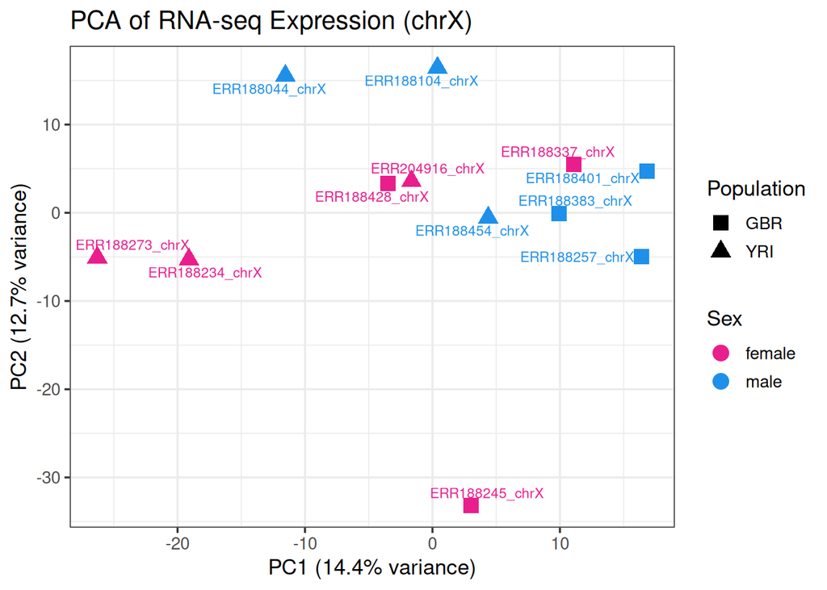

Figure 1: PCA of transcript-level FPKM expression across all chrX samples

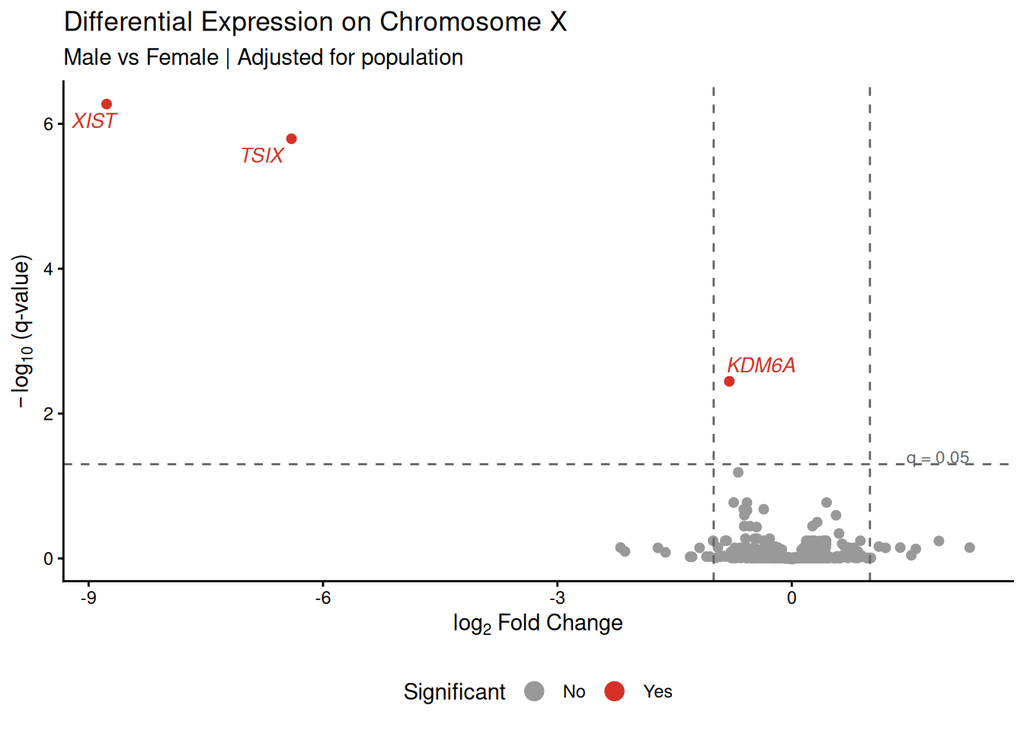

Figure 2: Volcano plots of differential gene expression on chrX. Fold change is calculated male relative to female, adjusted for population (YRI and GBR). Dashed horizontal line indicates q = 0.05 significance threshold.

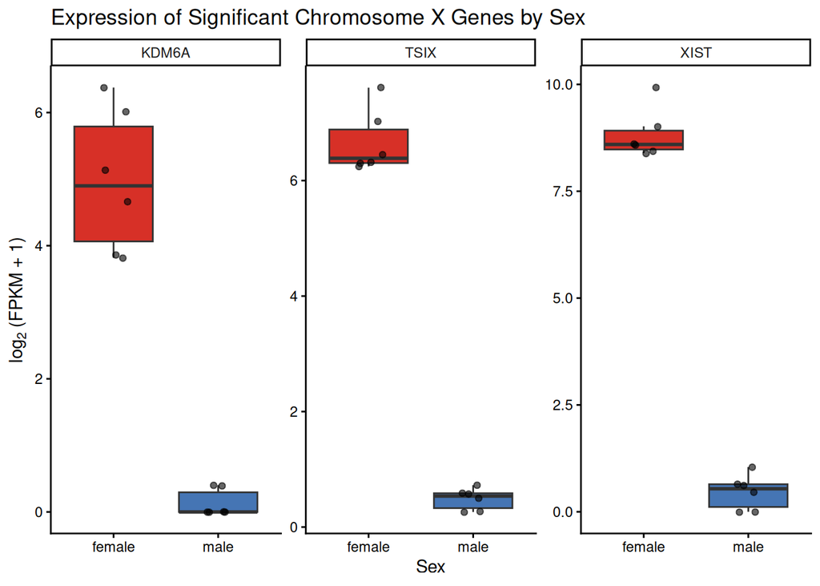

Figure 3: Expression of significant Chromosome X genes by sex (FPKM)

## Results

### Transcript Filtering

An initial set of 2,343 transcripts was extracted from the StringTie quantification step. To eliminate uninformative background noise and improve statistical power, transcripts with low variance across samples were pruned. Applying a filtration cutoff threshold of $rowVar > 1$ successfully yielded 1,095 high-confidence transcripts retained for exploratory and differential expression processing.

### Exploratory Variance Analysis

To understand global relationship structures within the filtered datasets, a Principal Component Analysis (PCA) was calculated on transcript-level Fragments Per Kilobase of transcript per Million mapped reads (FPKM) expression data.

### Differential Expression

Table 2: Significant differentially expressed transcripts (q < 0.05)

|  | geneNames | geneIDs | feature | id | fc | pval | qval |
| --- | --- | --- | --- | --- | --- | --- | --- |
| 1058 | TSIX | MSTRG.331 | transcript | 1058 | 0.012 | 9.1e-09 | 5.0e-06 |
| 1059 | XIST | MSTRG.332 | transcript | 1059 | 0.002 | 6.9e-09 | 5.0e-06 |
| 435 | KDM6A | MSTRG.148 | transcript | 435 | 0.032 | 3.1e-05 | 1.1e-02 |

Table 3: Significant differentially expressed genes (q < 0.05)

| feature | id | fc | pval | qval |
| --- | --- | --- | --- | --- |
| gene | MSTRG.332 | 0.002 | 9.3e-10 | 5.3e-07 |
| gene | MSTRG.331 | 0.012 | 5.6e-09 | 1.6e-06 |
| gene | MSTRG.233 | 0.574 | 1.9e-05 | 3.6e-03 |

Statistical testing on the curated genomic features revealed a highly localised set of differentially expressed targets. As mapped out in Figure 2, only three specific genes crossed the designated horizontal significance threshold of $q = 0.05$. Fold-change computations reflect expression levels of males relative to females; consequently, negative log<sub>2</sub> fold-change parameters pinpoint strong female-biased gene expression patterns.

The three significant genes identified are:

- **XIST (MSTRG.332):** Shows an extreme female bias with a fold change value of 0.00229 and a significance score ($q = 5.3 \times 10^{-7}$).
- **TSIX (MSTRG.331):** Displays an aligned female bias with an intermediate fold change metric of 0.01181 ($q = 1.6 \times 10^{-6}$).
- **KDM6A (MSTRG.233):** Reaches significant separation parameters with an adjusted fold change value of 0.57437 ($q = 3.6 \times 10^{-3}$).

## Discussion and Conclusion

### Biological Implications of Female-Biased Expression

The differential expression analysis of human Chromosome X transcripts revealed a highly localised regulatory signature. Only three genes - *XIST*, *TSIX*, and *KDM6A* - exhibited statistically significant expression differences between sexes ($q < 0.05$). All three candidates demonstrated explicit female-biased abundance. This tight localisation underscores the stringent evolutionary conservation governing sex-chromosome dosage mechanisms in humans.

### Mechanistic Synergy of XIST and TSIX

The identification of XIST (MSTRG.332) and TSIX (MSTRG.331) as the most statistically significant differentially expressed features aligns with established models of XCI (Lyon, 1961; Galupa and Heard, 2018). In female mammals, dosage compensation between XX and XY individuals is achieved by transcriptionally silencing one of the two female X chromosomes.

- **XIST Function:** This long non-coding RNA (lncRNA) is transcribed exclusively from the future inactive X chromosome ($X_i$). It physically coats the chromosome in cis, recruiting repressive chromatin-modifying complexes to initiate heterochromatin silencing.
- **TSIX Function:** Operating as an antisense lncRNA partner, TSIX is transcribed from the opposite strand (Lee and Lu, 1999) and overlaps the XIST locus. It acts as a negative regulator of XIST. Prior to inactivation, TSIX expression on the future active X chromosome ($X_a$) represses XIST accumulation, preserving transcription.

The binary expression profiles captured in the FPKM boxplots (Figure 3) — where both lncRNAs show near-zero baseline expression across all male samples — reflect this strict functional biology. Because males possess only a single, active X chromosome, the XIST/TSIX inactivation locus is never activated.

### Dosage Escape by KDM6A

The significant female bias observed in KDM6A (MSTRG.233) highlights a distinct biological phenomenon: XCI escape. KDM6A encodes a histone demethylase responsible for removing repressive H3K27me3 marks, thereby promoting transcriptionally active chromatin states.

# List of Acronyms

**DE**

Differential Expression

**FDR**

False Discovery Rate

**FPKM**

Fragments Per Kilobase of transcript per Million mapped reads

**GTF**

Gene Transfer Format

**PCA**

Principal Component Analysis

**QC**

Quality Control

**RNA**

Ribonucleic acid

**RNAseq**

RNA Sequencing

**TPM**

Transcripts Per Million

**XCI**

X-Chromosome Inactivation

**chrX**

Chromosome X

**lncRNA**

long non-coding RNA

**mRNA**

messenger RNA

## Reference

Balaton, B.P., Cotton, A.M. and Brown, C.J., 2015. Derivation of consensus inactivation status for X-linked genes from genome-wide studies. *Biology of Sex Differences*, 6, p.35. https://doi.org/10.1186/s13293-015-0053-7.

Galupa, R. and Heard, E., 2018. X-chromosome inactivation: A crossroads between chromosome architecture and gene regulation. *Annual Review of Genetics*, 52, pp.535–566. https://doi.org/10.1146/annurev-genet-120116-024611.

Lee, J.T. and Lu, N., 1999. Targeted mutagenesis of Tsix leads to nonrandom X inactivation. *Cell*, 97(2), pp.249–260. https://doi.org/10.1016/S0092-8674(00)80735-0.

Lyon, M.F., 1961. Gene action in the X-chromosome of the mouse. *Nature*, 190, pp.372–373. https://doi.org/10.1038/190372a0.